I think a ridgeline plot could be really cool… see this website on how to make one: https://r-graph-gallery.com/294-basic-ridgeline-plot.html I got some ideas from the website “from data to viz”

For the map, I think it would be really cool to show a density plot of the total scores for that site this would be density on the y axis and score 1-5 on the x axis here’s a website on how to make a density plot: https://r-graph-gallery.com/21-distribution-plot-using-ggplot2.html

Load libraries

```r
library(ggplot2)
library(ggridges)
library(googledrive)
library(googlesheets4)
library(dplyr)
library(tidyverse)
library(radiant.data)
```

Read in the data

```r
url <- "https://docs.google.com/spreadsheets/d/1cUz4WZ1CRHFicuVUt82kJ_mL9Ur861Dn1c0BYu3NmRY/edit#gid=0"

MPS_tracker_data <- read_sheet(url)
```

[output not shown]

[output not shown]

[output not shown]

[output not shown]

```
## ✔ Reading from "compiled_MPS".
```

```
## ✔ Range 'Sheet1'.
```

Practice making a ridgeline plot with the diamonds dataset

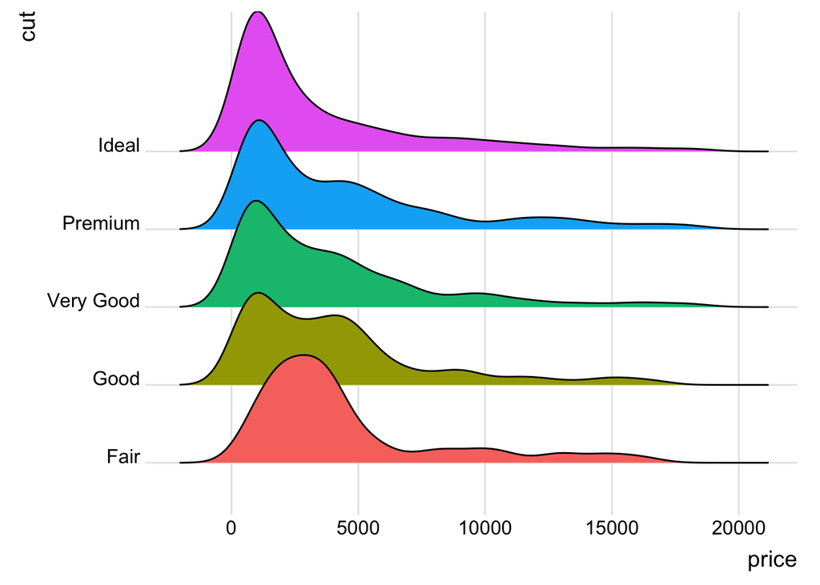

```r
ggplot(diamonds, aes(x = price, y = cut, fill = cut)) +
  geom_density_ridges() +
  theme_ridges() +
  theme(legend.position = "none")
```

Now let’s try that with our data

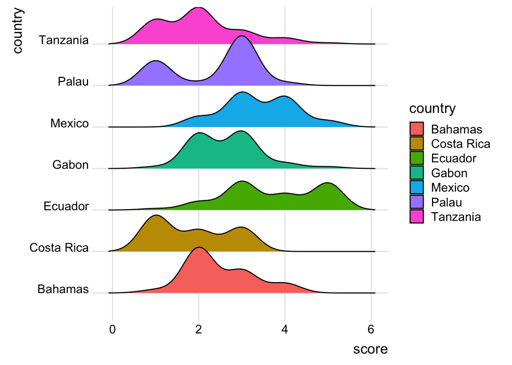

```r
# let's try to put the country on the y axis and the average score on the x axis

# make a mini data frame of what we want
# we have the problem that if we are to compare TOTAL scores accross countries, some countries have more sites and observations... this is why I'm going with the average for now
# ACTUALLY uh oh... you can't do this type of plot with the grouped averages

# # this object is useless right now:
# country_total_scores <- MPS_tracker_data |>
#   mutate(as.factor(country)) |>
#   group_by(country) |>
#   summarise(sum_score = mean(as.numeric(score), na.rm = TRUE), na.rm = TRUE) |>
#   na.omit() # how do I get rid of NAs?

# take out all rows that have "don't know or NA"
country_scores_no_na <- MPS_tracker_data[!(MPS_tracker_data$score == "Don't know or N/A"), ] |>
  na.omit() |>
  select(country, score)


ggplot(country_scores_no_na, aes(x = score, y = country, fill = country)) +
  geom_density_ridges(scale = 1.2) +
  theme_ridges()
```

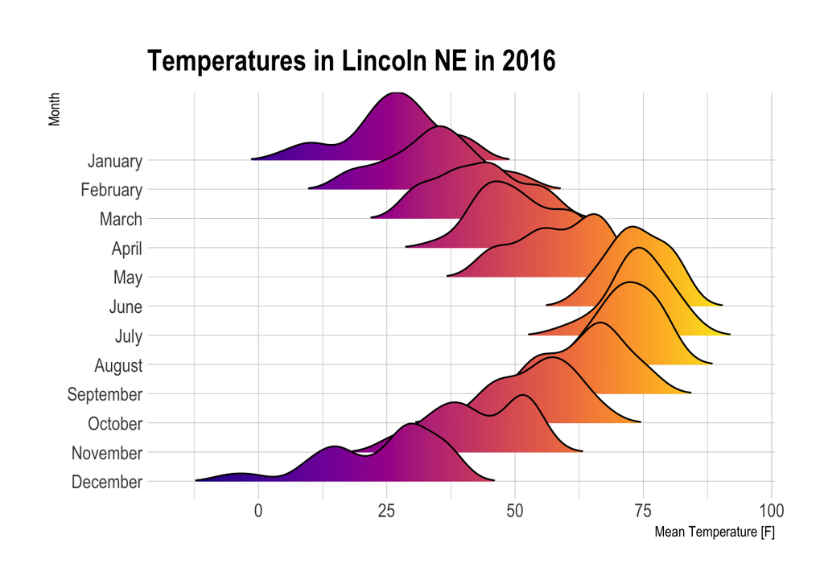

```r
# another tester one:
# library
library(ggridges)
library(ggplot2)
library(viridis)
library(hrbrthemes)
# Plot
ggplot(lincoln_weather, aes(x = `Mean Temperature [F]`, y = `Month`, fill = ..x..)) +
  geom_density_ridges_gradient(scale = 3, rel_min_height = 0.01) +
  scale_fill_viridis(name = "Temp. [F]", option = "C") +
  labs(title = 'Temperatures in Lincoln NE in 2016') +
  theme_ipsum() +
    theme(
      legend.position="none",
      panel.spacing = unit(0.1, "lines"),
      strip.text.x = element_text(size = 8)
    )
```

Try making a density plot comparing two things with transparency

```r
# compare surveillance and enforcement scores across all sites in 2022
# by the way I think I deleted "MPS_no_na" somehow so you'll have to recreate it later
MPS_no_na <- MPS_tracker_data |> na.omit()

surveillance_df <- MPS_tracker_data |>
  filter(category == "Surveilance and Enforcement",
         site == c("Bahamas EEZ",
                   "Celestun Fishery Refuge",
                   "Costa del Ecuador",
                   "National Parcs",
                   "PAN",
                   "Scorpion Reef National Park (Arrecife Alacrane Bioshpere Reserve)"))
```

[figure not shown]

```r
ggplot(data = surveillance_df,
       aes(x = score, group = site, fill = site)) +
  geom_density(adjust = 1.5, alpha = 0.5) +
  theme(legend.position = "bottom") +
  theme_ipsum() +
  labs(title = "Density of surveillance and enforcement scores across five sites")
```

# I have an idea! compare certain aspects of the enforcement strategy with the END GOAL. There are a couple end goals that we could go for:

- decreased bicatch (8 observations)
- community benefits (8 observations)
- decreased protected hunting (8 observations)
- declining infractions (8 observations)
- marine population status (8 observations) possibly more!

a useful question to ask could be something like: how does community involvement affect decreased bicatch… haha that could be interesting to understand! BUT we would need a different type of dataset for this… I don’t even think that this dataset is tidy yet!! we need to have a single row for an entire year at a certain site… how can we do this? pivot _wide() ?? obviously there is not much data for making specific inferences yet, but this program provides a framework to eventually do that… and we should brag about the fact that this is the first tool to track and monitor the marine enforcement efforts. This is why this is so important… say stuff like this in the next presentation!!

create pivot wide dataframe where each row is a years worth of data

```r
# create unique id column for each annual site entry (called "id")
MPS_tracker_data$id <- paste(MPS_tracker_data$year, MPS_tracker_data$site, sep = "_")

MPS_wide <- MPS_tracker_data |>
  pivot_wider(id_cols = id,
              names_from = sub_category,
              values_from = score) |>
  janitor::clean_names()

# where are all these null values coming from??
null_explore <- MPS_tracker_data |>
  filter(score == "NULL") # ----- welp not from here! there are no values that say "NULL"

# from looking at the wide data structure it looks like there are duplicate rows with different score values... some two some 3??
# --- one row that has this is 2020_Bahamas EEZ ... (2 for the sanctions and prosecutions) let's take a look at it
bahamas_eez_2020 <-
  MPS_tracker_data |> filter(id == "2020_Bahamas EEZ",
                             sub_category == "Sanctions & Prosecutions")
```

how many duplicate rows do we have

```r
print(duplicated(MPS_tracker_data)) # welp it looks like there are now duplicate rows... so why are there some multiple values in our wide data frame ??
```

[output not shown]

[output cut: 64 more lines]

Explore data w `dtab()`

```r
dtab(MPS_tracker_data)
```

| year | category | sub_category | indicator_type | score | country | site | comments | entered_by | id |
| --- | --- | --- | --- | --- | --- | --- | --- | --- | --- |
| 2020 | Surveillance and Enforcement | Surveillance Prioritization | Process Indicators | 3 | Bahamas | Bahamas EEZ | BNT has personnel assigned to specific MPA sites. The coverage isn't sufficient to provide persistent presence. There is a need for surveillance tools (e.g. binoculars). |  | 2020_Bahamas EEZ |
| 2020 | Community and Conservation Benefits | Decreased Bycatch | Impact Indicators | 3 | Bahamas | Bahamas EEZ | Very limited information about bycatch of protected species in directed fisheries. |  | 2020_Bahamas EEZ |
| 2020 | Community and Conservation Benefits | Decreased Protected Hunting | Impact Indicators | 3 | Bahamas | Bahamas EEZ | The team did not receive any specific information related to trends on impacts to protected species. |  | 2020_Bahamas EEZ |
| 2020 | Policies and Consequences | Sanctions & Prosecutions | Process Indicators | 2 | Bahamas | Bahamas EEZ | Sanctions vary widely. Efforts are needed to building understanding within the Police Force, AG office, and with prosecutors. Like above, there are efforts underway to close some of the loopholes that… |  | 2020_Bahamas EEZ |
| 2020 | Surveillance and Enforcement | Intelligence Sources | Process Indicators | 3 | Bahamas | Bahamas EEZ | Disperse between the agencies. Apparently driven by personal relationships, RBDF and DMR do receive tips from industry and other interested stakeholders about poaching. The information flow between th… |  | 2020_Bahamas EEZ |
| 2020 | Training and Mentorship | Staff Qualifications | Process Indicators | 2 | Bahamas | Bahamas EEZ | The DMR staff's broad swath of responsibilities and limited LE training creates a situation ripe for prioritizing other less dangerous tasks over investigating/responding to non-compliance. Interactio… |  | 2020_Bahamas EEZ |
| 2020 | Surveillance and Enforcement | Staff Numbers | Process Indicators | 3 | Bahamas | Bahamas EEZ | DMR's LE resources are scarce with a very limited number of employees dedicated to responding to ongoing or suspected poaching. The other agencies possess a higher level of LE personnel, but those res… |  | 2020_Bahamas EEZ |
| 2020 | Training and Mentorship | Standard Operating Procedures | Process Indicators | 2 | Bahamas | Bahamas EEZ | DMR and BNT appear to have limited SOPs and operational guidance to support field operatiosn. RBDF, RBPF, and Customs have a more robust system for training their people and ensuring consistent result… |  | 2020_Bahamas EEZ |
| 2020 | Policies and Consequences | Scientific Monitoring | Process Indicators | 3 | Bahamas | Bahamas EEZ | Studies exist for the lobster fishery to maintain its MSC certification. The other fisheries are subject to a variety of levels of assessment and room exists for increasing the level of knowledge abou… |  | 2020_Bahamas EEZ |
| 2020 | Community and Conservation Benefits | Community Benefits | Impact Indicators | 3 | Bahamas | Bahamas EEZ | Certification on Bahamian fisheries has led to increase benefits to the community. The family islands remain very dependant on marine resources. |  | 2020_Bahamas EEZ |

[output cut: 934 more lines]

Cases where there are duplicate scores for some reason: - 2020 bahamas eez has two entries for sanctions and prosecutions - many more

First let’s try making a corrplot with all these variables:

```r
library(corrplot)
#MPS_wide_num <- as.numeric(MPS_wide)
# i think that cor requires matrix format
MPS_wide_matrix <- data.matrix(MPS_wide, rownames.force = NA)
#MPS_cor <- cor(MPS_wide_matrix, use = "complete.obs")

#corrplot(MPS_cor, method = "number")

# check class of values
#class(MPS_wide[5,20])
#library(Hmisc)
#all_cor <- rcorr(MPS_wide_matrix)
#all_cor # running this will give a very large output so it's commented out here
# BUT we found some interesting correlations!! Let's see if we can test the significance
```

```r
# try the function unnest():
MPS_unnest <- unnest(MPS_wide, cols = c(international_institutional_collaboration))
MPS_unnest <- unnest(MPS_unnest, cols = c(national_institutional_collaboration))
MPS_unnest <- unnest(MPS_unnest, cols = c(staff_numbers))
MPS_unnest <- unnest(MPS_unnest, cols = c(vessel_availability))
MPS_unnest <- unnest(MPS_unnest, cols = c(community_benefits))
MPS_unnest <- unnest(MPS_unnest, cols = c(sanctions_prosecutions))
MPS_unnest <- unnest(MPS_unnest, cols = c(standard_operating_procedures))
MPS_unnest <- unnest(MPS_unnest, cols = c(fishing_sector_collaboration))
MPS_unnest <- unnest(MPS_unnest, cols = c(funding))

# WARNING: THIS changed UP THE DATA.. PROBABLY SHOULDN'T USE IT NOT SURE WHAT I JUST DID
# JUST FOR FUN LET'S SEE IF WE CAN MAKE A SCATTERPLOT WITH IT

# don't work m8
# ggplot(data = MPS_unnest, aes(x = funding, y = decreased_protected_hunting)) + geom_point()



# national_institutional_collaboration,
                                        # staff_numbers,
                                        # vessel_availability,
                                        # community_benefits,
                                        # sanctions_prosecutions,
                                        # standard_operating_procedures,
                                        # fishing_sector_collaboration,
                                        # funding

# --- ok let's try a different way I found online:
#MPS_unnest <- setNames(with(MPS_wide, data.frame(rep(id,lengths(staff_numbers)),unlist(staff_numbers))),names(MPS_wide))
```

### Scatter Plot

Let’s plot some of the things that are correlated with each other to see if we can justify putting scatter plot functionality into the shiny app

```r
## see if these correlations are actually significant
cor.test(MPS_wide$decreased_protected_hunting, MPS_wide$surveillance_prioritization)
```

```
##
##  Pearson's product-moment correlation
##
## data:  MPS_wide$decreased_protected_hunting and MPS_wide$surveillance_prioritization
## t = 5.7118, df = 6, p-value = 0.001247
## alternative hypothesis: true correlation is not equal to 0
## 95 percent confidence interval:
##  0.6084018 0.9854910
## sample estimates:
##      cor
## 0.919054
```

```r
# = significant
cor.test(MPS_wide$declining_infractions, MPS_wide$surveillance_prioritization)
```

```
##
##  Pearson's product-moment correlation
##
## data:  MPS_wide$declining_infractions and MPS_wide$surveillance_prioritization
## t = 4.0389, df = 6, p-value = 0.006811
## alternative hypothesis: true correlation is not equal to 0
## 95 percent confidence interval:
##  0.3783025 0.9732854
## sample estimates:
##       cor
## 0.8550394
```

```r
# = significant
cor.test(MPS_wide$marine_population_status, MPS_wide$surveillance_prioritization)
```

```
##
##  Pearson's product-moment correlation
##
## data:  MPS_wide$marine_population_status and MPS_wide$surveillance_prioritization
## t = 4.1849, df = 6, p-value = 0.005782
## alternative hypothesis: true correlation is not equal to 0
## 95 percent confidence interval:
##  0.4041437 0.9748471
## sample estimates:
##       cor
## 0.8630339
```

```r
# = significant
cor.test(MPS_wide$sighting_to_apprehension, MPS_wide$decreased_bycatch)
```

```
##
##  Pearson's product-moment correlation
##
## data:  MPS_wide$sighting_to_apprehension and MPS_wide$decreased_bycatch
## t = 4.556, df = 6, p-value = 0.003867
## alternative hypothesis: true correlation is not equal to 0
## 95 percent confidence interval:
##  0.4642168 0.9782733
## sample estimates:
##      cor
## 0.880771
```

```r
# = significant
cor.test(MPS_wide$decreased_protected_hunting, MPS_wide$surveillance_prioritization)
```

```
##
##  Pearson's product-moment correlation
##
## data:  MPS_wide$decreased_protected_hunting and MPS_wide$surveillance_prioritization
## t = 5.7118, df = 6, p-value = 0.001247
## alternative hypothesis: true correlation is not equal to 0
## 95 percent confidence interval:
##  0.6084018 0.9854910
## sample estimates:
##      cor
## 0.919054
```

```r
# =
cor.test(MPS_wide$decreased_protected_hunting, MPS_wide$surveillance_prioritization)
```

```
##
##  Pearson's product-moment correlation
##
## data:  MPS_wide$decreased_protected_hunting and MPS_wide$surveillance_prioritization
## t = 5.7118, df = 6, p-value = 0.001247
## alternative hypothesis: true correlation is not equal to 0
## 95 percent confidence interval:
##  0.6084018 0.9854910
## sample estimates:
##      cor
## 0.919054
```

```r
# =
cor.test(MPS_wide$decreased_protected_hunting, MPS_wide$surveillance_prioritization)
```

```
##
##  Pearson's product-moment correlation
##
## data:  MPS_wide$decreased_protected_hunting and MPS_wide$surveillance_prioritization
## t = 5.7118, df = 6, p-value = 0.001247
## alternative hypothesis: true correlation is not equal to 0
## 95 percent confidence interval:
##  0.6084018 0.9854910
## sample estimates:
##      cor
## 0.919054
```

```r
# =
cor.test(MPS_wide$decreased_protected_hunting, MPS_wide$surveillance_prioritization)
```

```
##
##  Pearson's product-moment correlation
##
## data:  MPS_wide$decreased_protected_hunting and MPS_wide$surveillance_prioritization
## t = 5.7118, df = 6, p-value = 0.001247
## alternative hypothesis: true correlation is not equal to 0
## 95 percent confidence interval:
##  0.6084018 0.9854910
## sample estimates:
##      cor
## 0.919054
```

```r
# =
```

try making a scatter plot with regression line for some variable comparisons:

```r
# ggplot(data = MPS_wide,
#        aes(x = vessel))
```

Line graph over time:

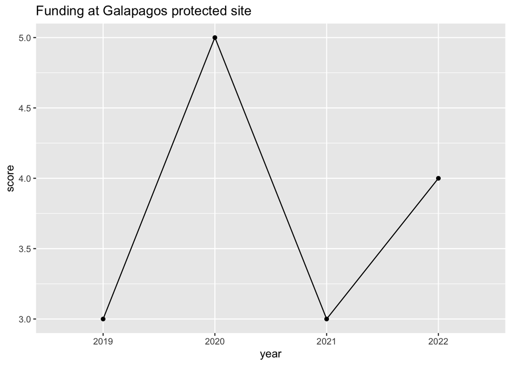

```r
dat_1 <- MPS_tracker_data |>
  filter(str_detect(site, "Galapagos"),
         sub_category == "Funding") |>
  na.omit()

ggplot(data = dat_1,
       mapping = aes(x = year, y = score, group = 1)) +
  geom_line() +
  geom_point() +
  labs(title = "Funding at Galapagos protected site")
```